# Dynamiques spatio-temporelles des oiseaux communs en Martinique

Stage M1 BEE - CESCO-MNHN | STOC-EPS 2015-2025

Auteur·rice

Mylène Vitry

Date de publication

24 septembre 2026

## 1 Introduction

Le Suivi Temporel des Oiseaux Communs (STOC-EPS) est un programme de sciences participatives coordonné par le Muséum National d’Histoire Naturelle (MNHN) et permettant de suivre l’abondance des oiseaux communs. En Martinique, ce suivi porte, après nettoyage, sur **65 sites** et **650 points d’écoute** (2015-2025, 11 ans, **2 passages/an agrégés** en une valeur annuelle — le maximum inter-passages).

Ce rapport présente les résultats des analyses de **tendances temporelles d’abondance apparente** par milieu, en lien avec l’**usage apparent d’habitat** par groupe et par espèces.

## 2 Données

### 2.1 Jeu de données STOC-EPS Martinique

| Indicateur | Valeur |
| --- | --- |
| Période | 2015-2025 (11 ans) |
| Nombre de sites | 65 |
| Nombre de points d'écoute | 650 |
| Nombre d'espèces (hors migrateurs/marins) | 52 |
| Nombre d'observateurs | 39 |
| Stabilité de l'effort (CV* des points/an) | 5.7 % |

*Effort d’échantillonnage stable ~ CV < 10%

### 2.2 Classification des habitats

Chaque milieu regroupe plusieurs sous-habitats, détaillés dans le tableau ci-dessous :

Composition des habitats STOC-EPS Martinique

| Habitat | Milieu | N points | % points |
| --- | --- | --- | --- |
| Foret seche | Naturel | 186 | 28.6 |
| Urbain | Anthropise | 140 | 21.5 |
| Agriculture | Anthropise | 134 | 20.6 |
| Foret humide | Naturel | 130 | 20.0 |
| Mangrove | Naturel | 30 | 4.6 |
| Plage | Hors strate (plage) | 30 | 4.6 |

### 2.3 Carte des points STOC-EPS

[interactive chart not shown]

### 2.4 Composition de la communauté

| Statut | N espèces | N individus | % espèces | % individus |
| --- | --- | --- | --- | --- |
| Natifs (endémiques + indigènes) | 34 | 134810 | 65.4 | 84.1 |
| Introduits | 18 | 25523 | 34.6 | 15.9 |

Détail des natifs : endémiques vs indigènes

| Statut détaillé | N espèces | N individus | % espèces | % individus |
| --- | --- | --- | --- | --- |
| Endémique | 15 | 24647 | 44.1 | 18.3 |
| Indigène | 19 | 110163 | 55.9 | 81.7 |

En Martinique, **les natifs dominent** la communauté (en espèces et en individus), contrairement à La Réunion où les introduits dominent.

### 2.5 Espèces les plus abondantes et communes

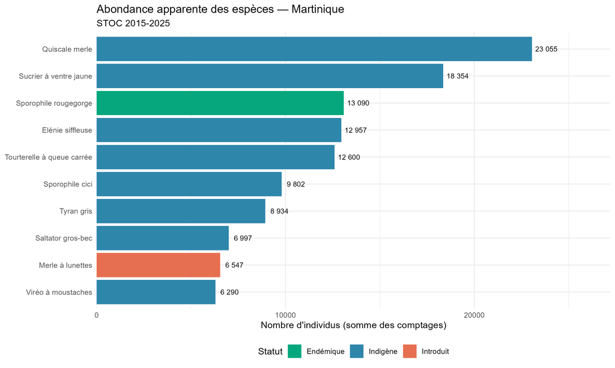

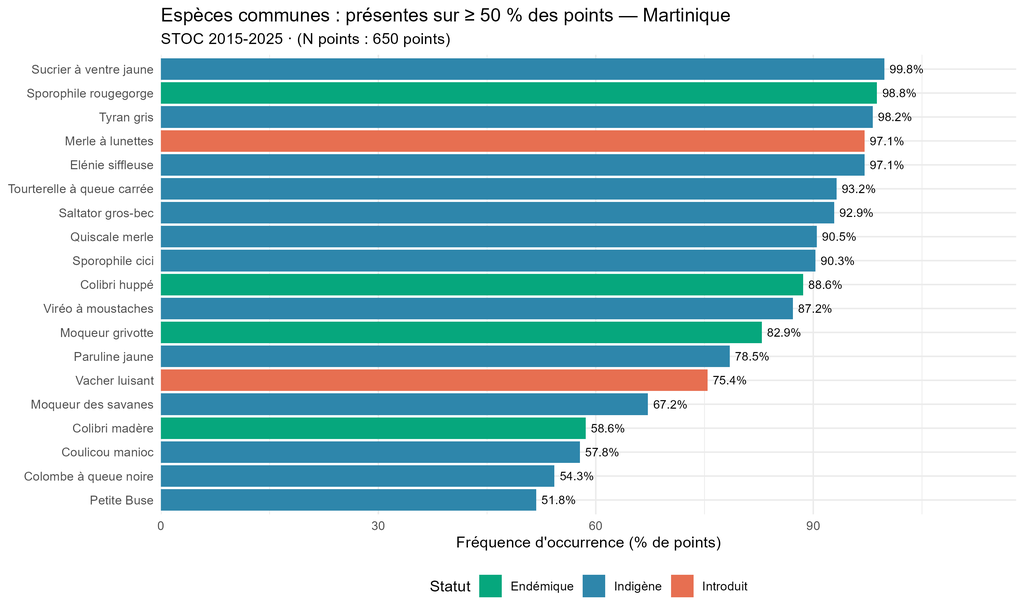

Ces classements utilisent l’**abondance apparente** : les oiseaux ne sont pas tous détectés de la même façon selon l’espèce et le milieu (détectabilité non corrigée), et un même point est recompté chaque année pendant 11 ans (les comptages ne sont donc pas indépendants). Le nombre d’espèces (richesse) est l’indicateur le plus fiable, tandis que le nombre de contacts et d’individus donne surtout un ordre de grandeur et sont à interpréter avec prudence.

### 2.6 Cartes de répartition par espèce

La taille des cercles est proportionnelle au logarithme de l’abondance apparente moyenne par visite (échelle commune à toutes les espèces).

[interactive chart not shown]

## 3 Usage apparent d’habitat

Analyse restreinte aux espèces communes (Vimont *et al.* 2025 : ≥ 5 sites/an, ≥ 2 habitats), hors espèces aériennes et marines. L’**usage relatif** (IRR) compare l’abondance d’une espèce dans un habitat à la moyenne de ses habitats : **> ×1 sur-utilisation, < ×1 évitement, = ×1 usage moyen**. Significativité : intervalle de confiance à 95 % **exclut ×1** (usage moyen). Au niveau des groupes, les p-values sont corrigées pour les tests multiples (**p FDR**, Benjamini-Hochberg) : **p FDR < 0,05** = significatif après correction.

### 3.1 Par groupe

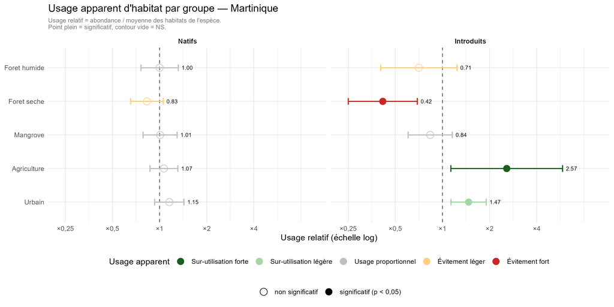

Usage apparent d'habitat par groupe (I² = hétérogénéité inter-espèces)

| Groupe | Habitat | Usage relatif | Lecture | I² | p (FDR) |
| --- | --- | --- | --- | --- | --- |
| Introduits | Agriculture | ×2.57 [1.13–5.85] | sur-utilise fortement | 92 % | 0.050 |
|  | Foret humide | ×0.71 [0.40–1.24] | usage moyen (NS) | 65 % | 0.220 |
|  | Foret seche | ×0.42 [0.25–0.69] | évite fortement | 71 % | 0.025 |
|  | Mangrove | ×0.84 [0.60–1.16] | usage moyen (NS) | 0 % | 0.220 |
|  | Urbain | ×1.47 [1.13–1.90] | sur-utilise légèrement | 31 % | 0.025 |
| Natifs | Agriculture | ×1.07 [0.87–1.31] | usage moyen (NS) | 84 % | 0.880 |
|  | Foret humide | ×1.00 [0.76–1.32] | usage moyen (NS) | 89 % | 1.000 |
|  | Foret seche | ×0.83 [0.65–1.05] | usage moyen (NS) | 90 % | 0.460 |
|  | Mangrove | ×1.01 [0.78–1.30] | usage moyen (NS) | 56 % | 1.000 |
|  | Urbain | ×1.15 [0.93–1.43] | usage moyen (NS) | 81 % | 0.460 |

### 3.2 Par espèce

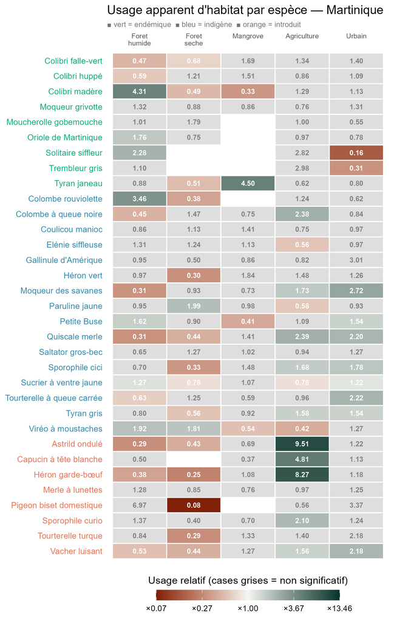

## 4 Tendances temporelles d’abondance apparente

Tendances estimées par la Routine GLMM du MNHN (Vimont *et al.* 2025), classées selon ses 8 catégories : Augmentation forte, Augmentation modérée à forte, Augmentation modérée, Stable, Déclin modéré, Déclin modéré à fort, Déclin fort, Incertain.

### 4.1 Tendance globale

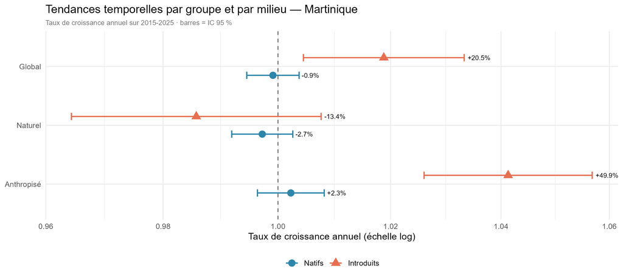

Tendance par milieu et par groupe (variation d'abondance apparente sur la période)

| Groupe | Naturel | Anthropisé |
| --- | --- | --- |
| Introduits | -13.4 % | +49.9 % |
| Natifs | -2.7 % | +2.3 % |

### 4.3 Croisement usage ↔︎ tendance

Croisement descriptif (aucun test) : usage apparent (agrégé par milieu) × tendance (usage relatif moyen sans IC)

| Groupe | Milieu | Usage relatif moyen | Tendance |
| --- | --- | --- | --- |
| Introduits | Anthropise | ×1.94 | +49.9 % |
|  | Naturel | ×0.63 | -13.4 % |
| Natifs | Anthropise | ×1.11 | +2.3 % |
|  | Naturel | ×0.94 | -2.7 % |

Les introduits **augmentent le plus dans les milieux qu’ils sur-utilisent** (anthropisé), et n’augmentent pas dans les milieux qu’ils évitent (naturel).

## 5 Fiches espèces

Au total, **33 espèces** ont été analysées (usage et tendance estimés), dont :

- **25 natives** (9 endémiques, 16 indigènes) : 8 en augmentation, 8 en déclin, 3 stables et 6 incertaines ;
- **8 introduites** : 3 en augmentation, 1 en déclin, 1 stables et 3 incertaines.

### 5.1 Trembleur gris — Augmentation forte (+109.5% global)

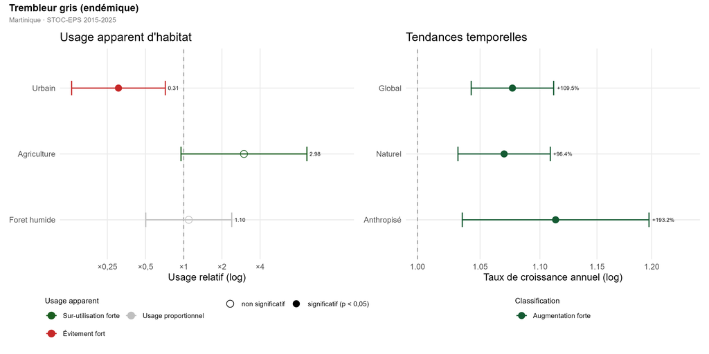

### 5.2 Tyran janeau — Augmentation forte (+68.8% global)

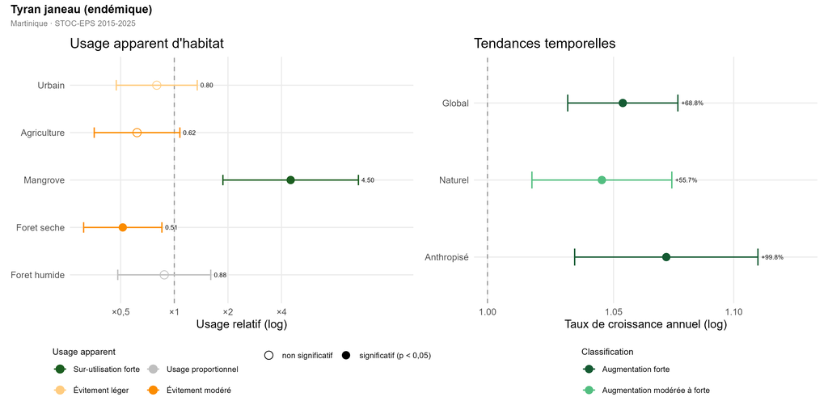

### 5.3 Tourterelle à queue carrée — Augmentation modérée à forte (+38.5% global)

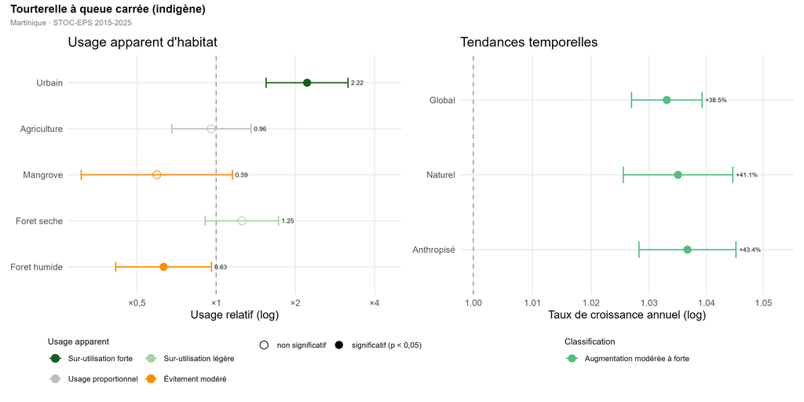

### 5.4 Colombe rouviolette — Augmentation modérée (+32.7% global)

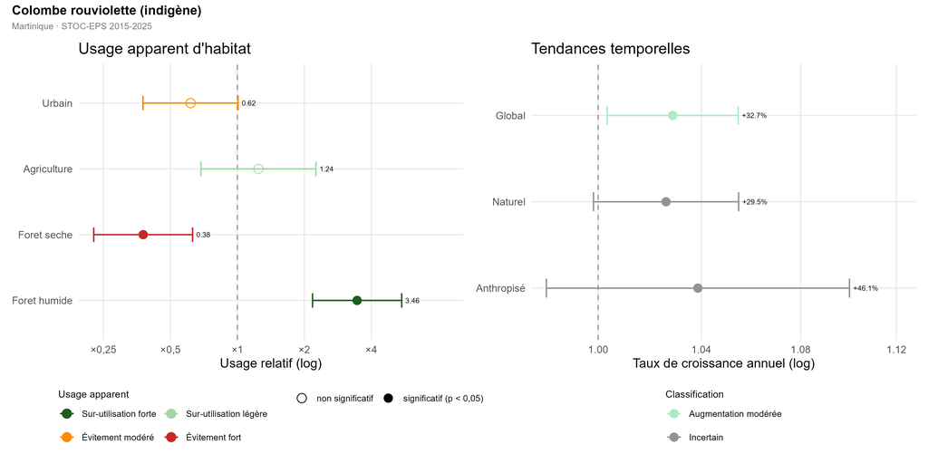

### 5.5 Elénie siffleuse — Augmentation modérée (+23.2% global)

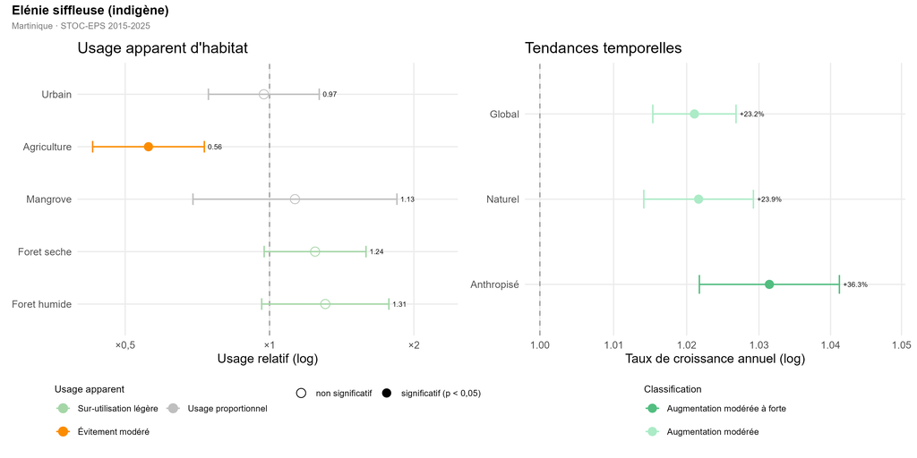

### 5.6 Tyran gris — Augmentation modérée (+14.9% global)

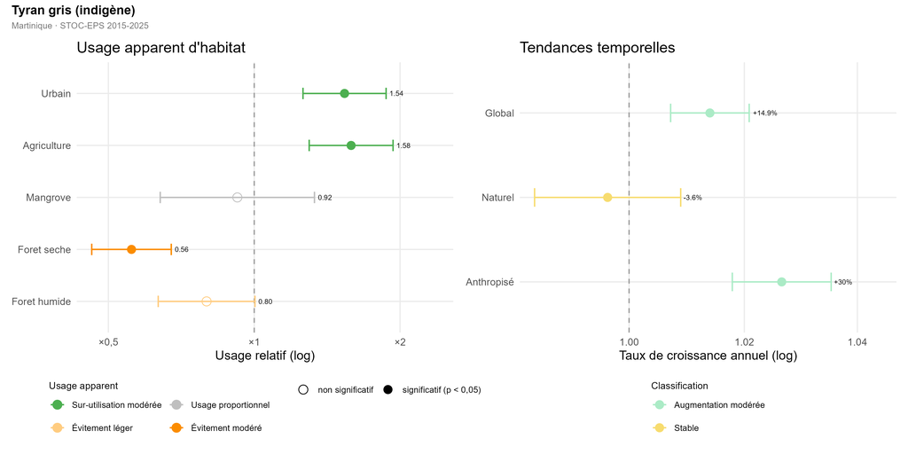

### 5.7 Viréo à moustaches — Augmentation modérée (+12% global)

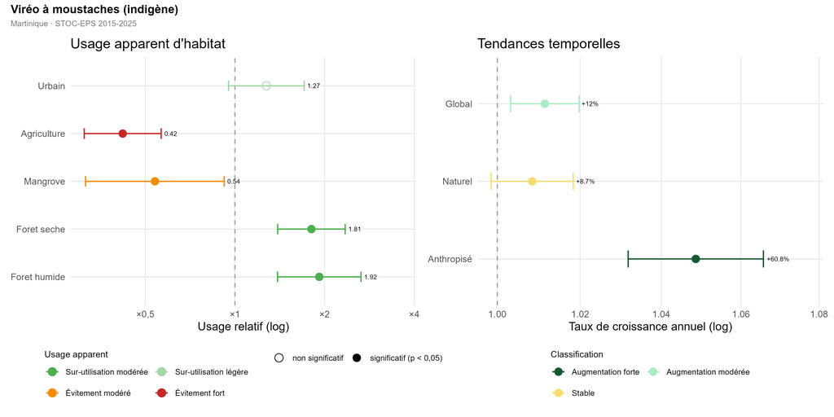

### 5.8 Sucrier à ventre jaune — Augmentation modérée (+5.6% global)

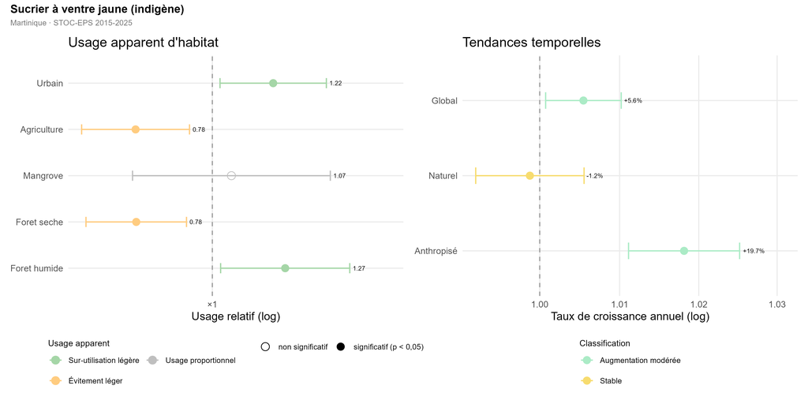

### 5.9 Astrild ondulé — Augmentation forte (+327.7% global)

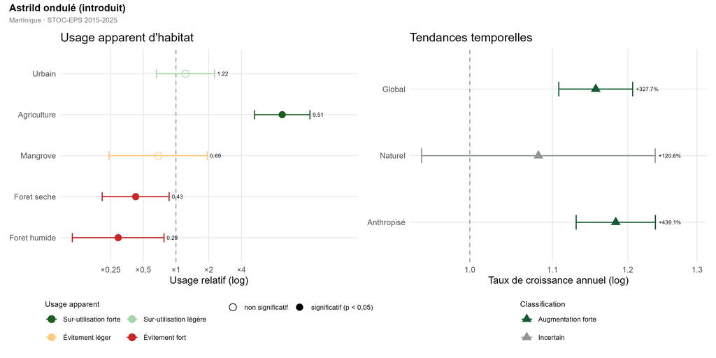

### 5.10 Tourterelle turque — Augmentation forte (+293.4% global)

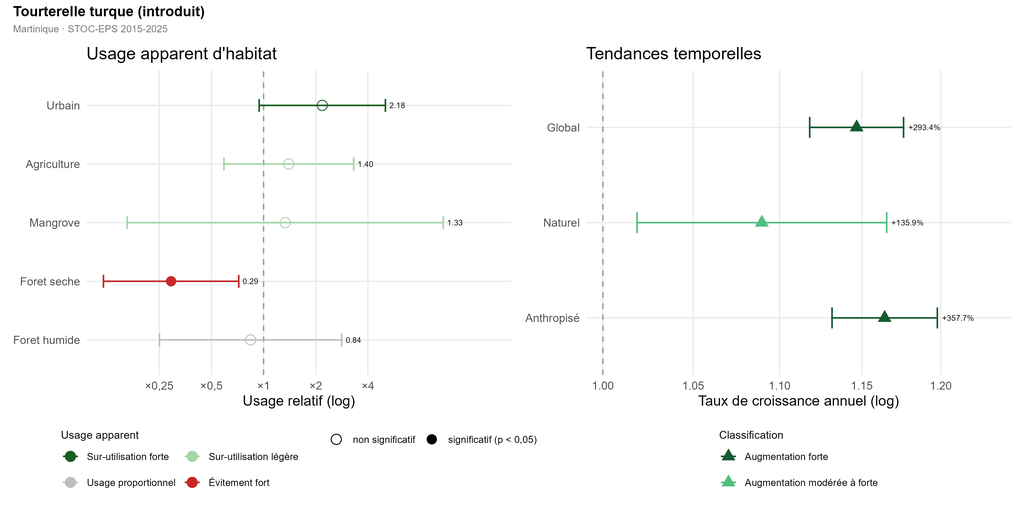

### 5.11 Vacher luisant — Augmentation forte (+61.4% global)

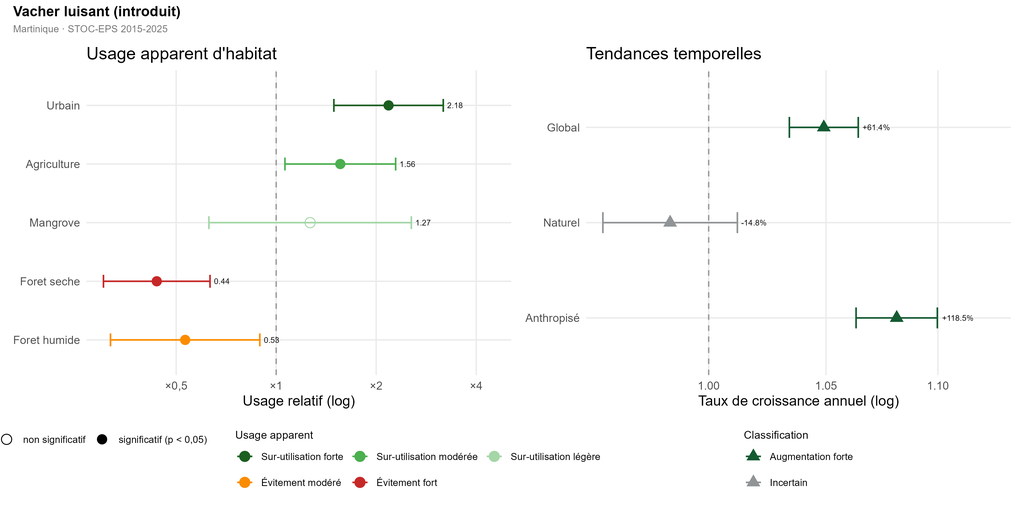

### 5.12 Moucherolle gobemouche — Déclin fort (-71.5% global)

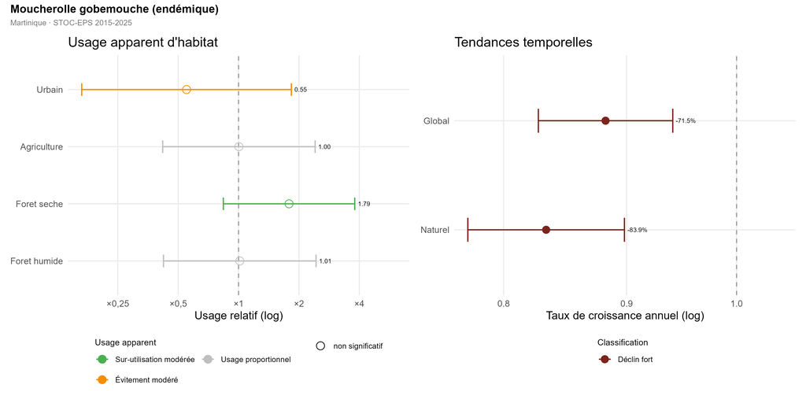

### 5.13 Colibri falle-vert — Déclin modéré à fort (-42.3% global)

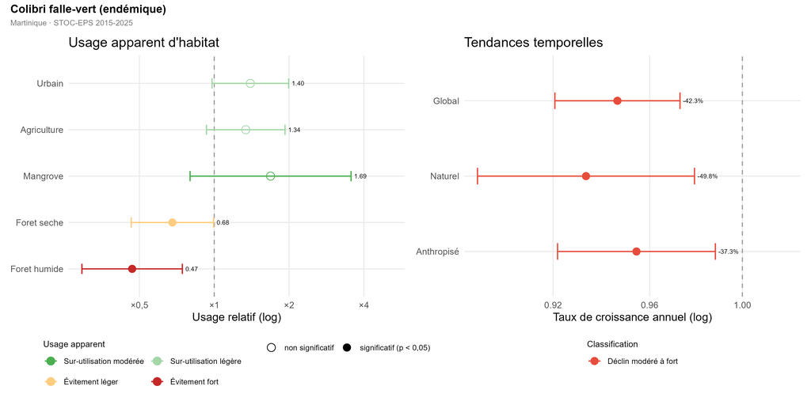

### 5.14 Colibri madère — Déclin modéré (-20.8% global)

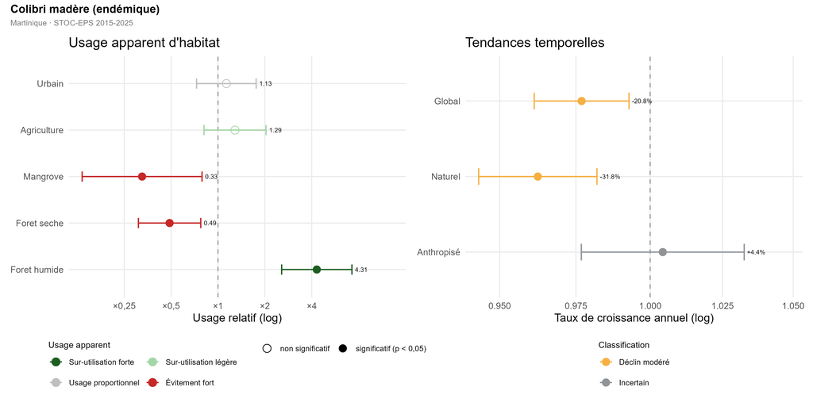

### 5.15 Moqueur grivotte — Déclin modéré (-15.9% global)

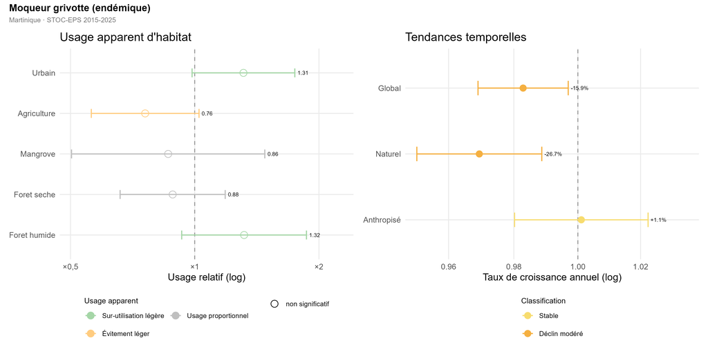

### 5.16 Moqueur des savanes — Déclin modéré (-29.3% global)

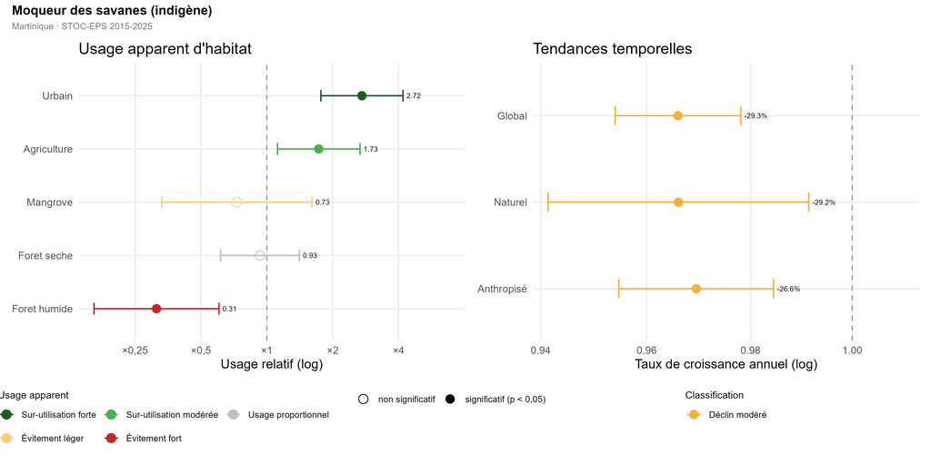

### 5.17 Coulicou manioc — Déclin modéré (-28.3% global)

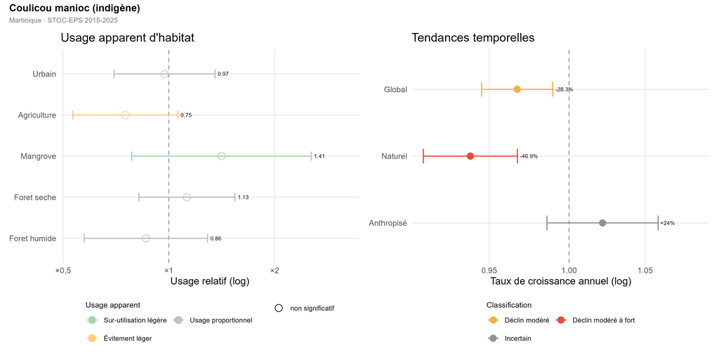

### 5.18 Sporophile cici — Déclin modéré (-25.6% global)

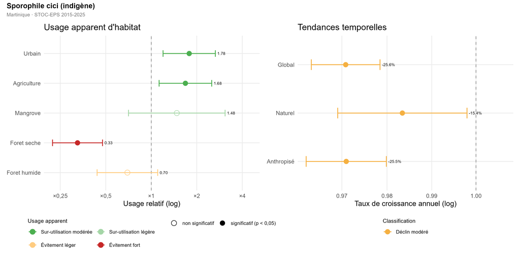

### 5.19 Quiscale merle — Déclin modéré (-16.8% global)

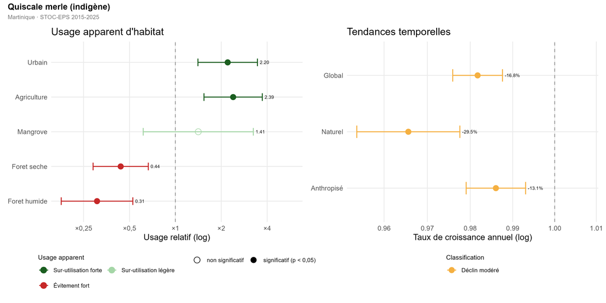

### 5.20 Sporophile curio — Déclin modéré à fort (-45.9% global)

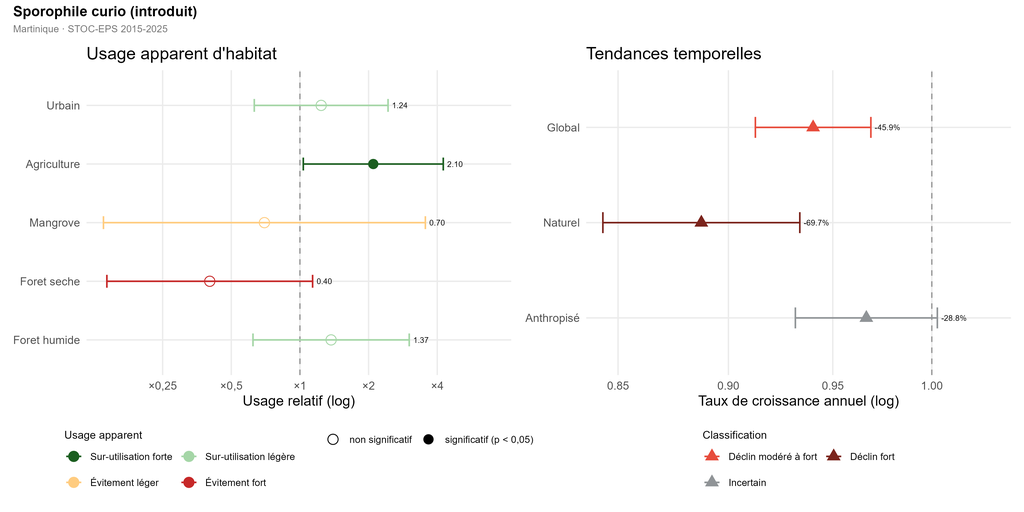

### 5.21 Colibri huppé — Stable (-3.5% global)

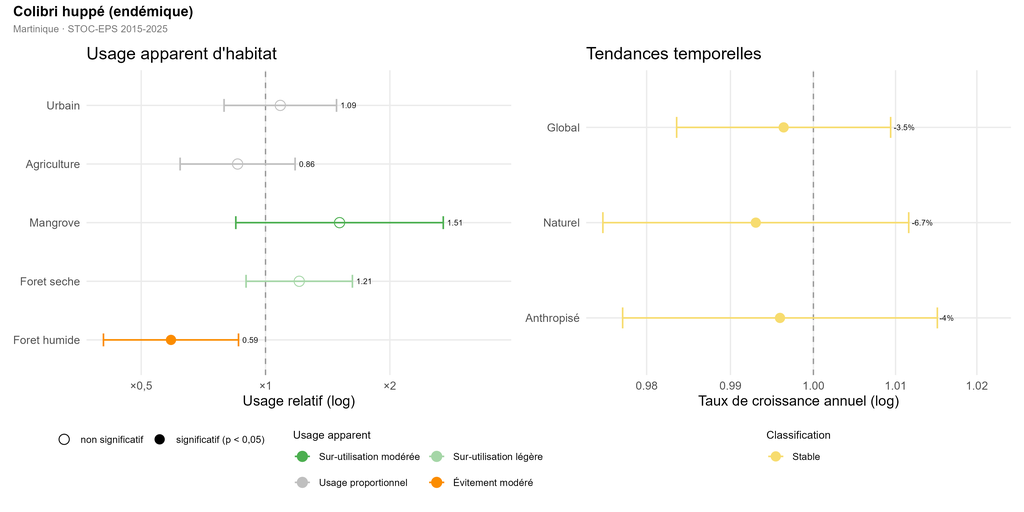

### 5.22 Paruline jaune — Stable (-4.2% global)

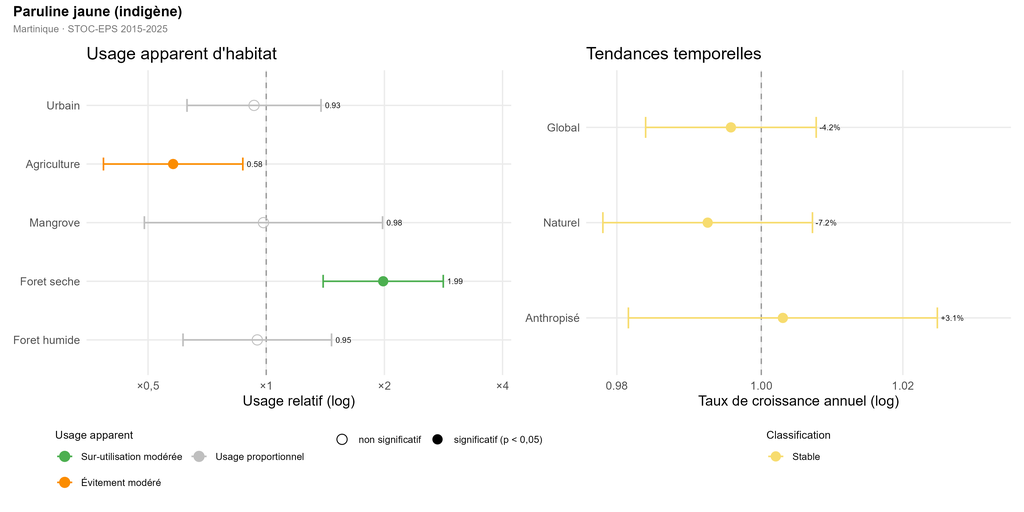

### 5.23 Saltator gros-bec — Stable (+0.8% global)

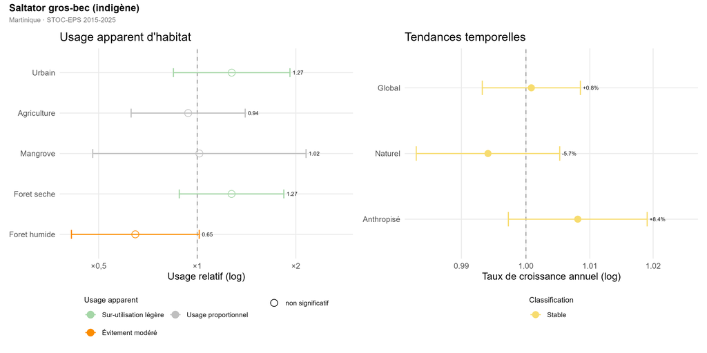

### 5.24 Merle à lunettes — Stable (-3% global)

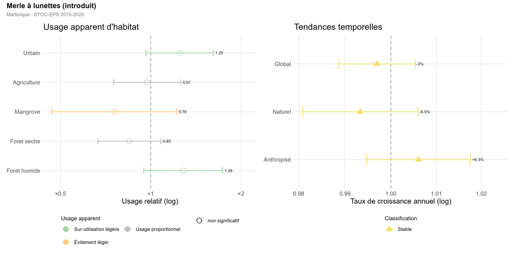

### 5.25 Oriole de Martinique — Incertain (-29.4% global)

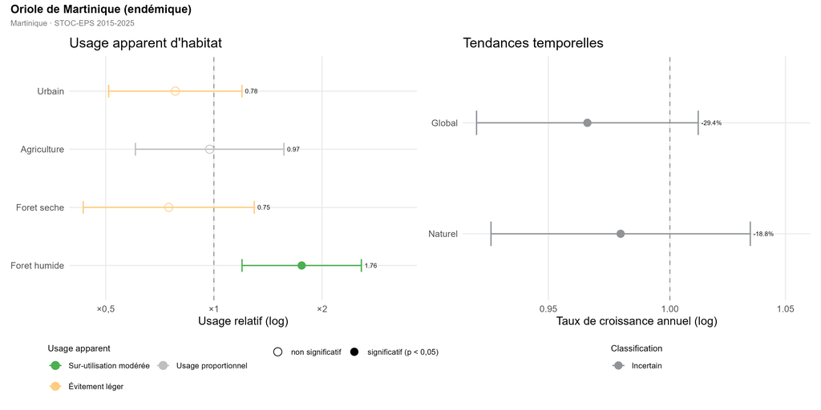